# ggplot2 exercises

Leonard Blaschek

## 1. Density curves

#### Task:

Create density curves (`geom_density()`) for the relative lignin content (`rel_lignin`). The fill of the curve should correspond to their `type` (mutant or WT) and be semi-transparent (`alpha = 0.5`). Lastly, get rid of the hideous grey background by applying our custom `theme_sulis()`.

#### Bonus:

Check the arguments of `coord_cartesian()` to figure out how to remove the scale expansion (*i.e.* the little gap between 0 and the axis line).

#### Data file:

`"data/Sulis2023_fig3G.tsv"`

```r
# write your code in this code chunk; execute all code within the chunk your cursor is in with ctrl+shift+enter
data <- read_tsv("data/Sulis2023_fig3G.tsv")
```

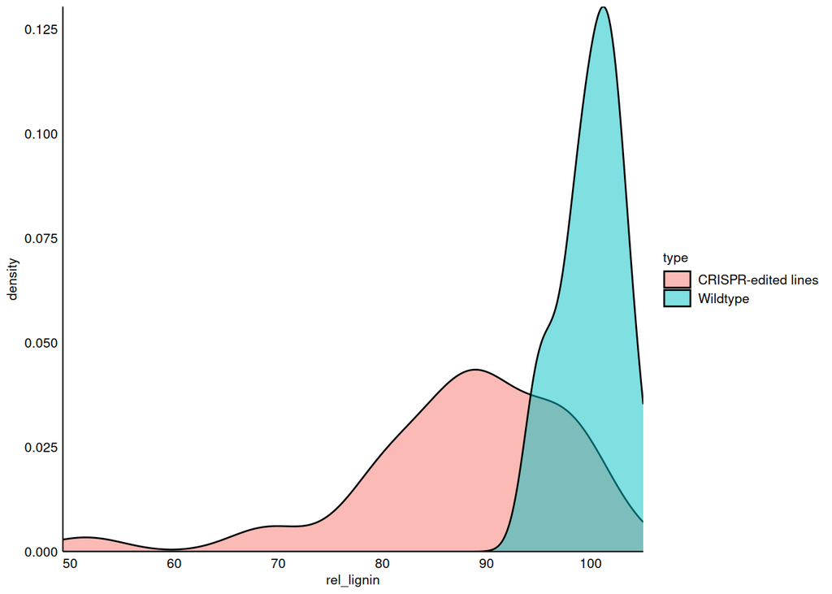

```r
ggplot(
  data = data,
  aes(
    x = rel_lignin,
    fill = type
  )
) +
  geom_density(alpha = 0.5) +
  coord_cartesian(expand = FALSE) +
  theme_sulis()
```

## 2. Violin and boxplots

#### Data:

`"data/Sulis2023_predictions.tsv"`

#### Hint:

If you want to use a continuous variable as a grouping factor on a discrete x-axis, you might have to wrap it inside `as.factor()`.

```r
data <- read_tsv("data/Sulis2023_predictions.tsv")
```

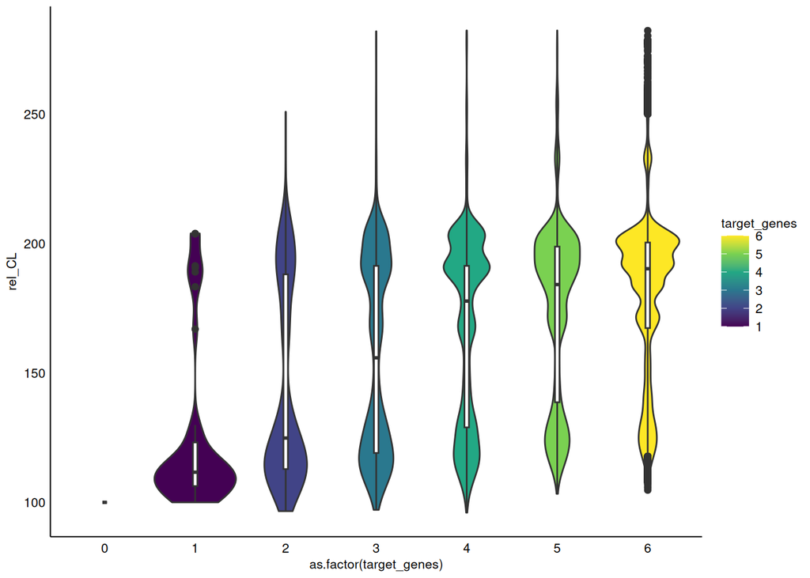

```r
ggplot(
  data = data,
  aes(
    x = as.factor(target_genes),
    y = rel_CL
  )
) +
  geom_violin(aes(fill = target_genes)) +
  geom_boxplot(width = 0.05) +
  scale_fill_viridis_c() +
  theme_sulis()
```

# 3. 2D density and facets

#### Task:

Using the data of mutant predictions, plot the relative stem volume (`rel_volume`) against relative lignin content (`rel_lignin`). You can start by trying `geom_point()`, but you’ll see that the enormous number of points creates a black mass that is difficult to interpret. Instead, try `geom_density2d_filled()` to get a 2D density map of the predictions.

This looks OK, but what if you want to compare those densities relative to the number of targeted genes? `facet_wrap()` lets you split your figure into smaller facets, each representing a subgroup of the data. Use `facet_wrap()` to split your plot by `target_genes`. Lastly, add white dashed lines at 100% of x and y axes for orientation (check `?geom_abline()`).

#### Bonus:

Seven facets look a bit inelegant, and the `0` facet (*i.e.* WT) is useless anyways. Going a bit beyond the scope of this workshop, replace your data argument with `data = data |> filter(target_genes > 0)` to remove the `0` facet (assuming you named your data frame `data`).

Also, perhaps give it another colour scheme?

#### Data:

`"data/Sulis2023_predictions.tsv"`

#### Hint:

The unequal number of data points in the different facets makes the densities in facets with fewer target genes invisible. To calculate the bins independently in each facet, set the `geom_density2d_filled()` option `contour_var` to `"ndensity"`.

```r
data <- read_tsv("data/Sulis2023_predictions.tsv")
```

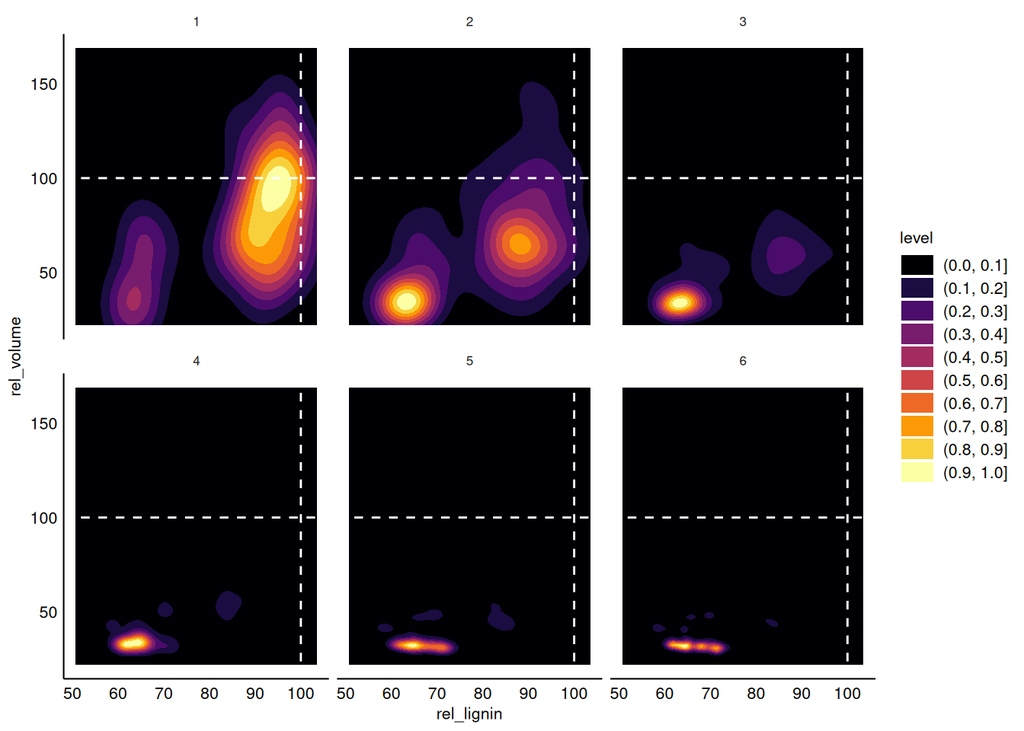

```r
ggplot(
  data = data |> filter(target_genes > 0),
  aes(
    x = rel_lignin,
    y = rel_volume
  )
) +
  geom_density2d_filled(contour_var = "ndensity") +
  scale_fill_viridis_d(option = "B") +
  geom_hline(yintercept = 100, colour = "white", linetype = "dashed") +
  geom_vline(xintercept = 100, colour = "white", linetype = "dashed") +
  theme_sulis() +
  facet_wrap(~target_genes)
```